# tm_viz_channels

## Entorno de trabajo

Estos notebooks trabajan con esta estructura de directorios

```
dir_raiz ----+-----datos      # Se guardan los datos, cada dataset en un directorio independiente
             +-----notebooks  # Se guardan los notebooks en R
```

## Requisitos

- Disponer de una o varias descargas de canales Telegram

## Importamos librerías

```
## <locale>
## Numbers:  123,456.78
## Formats:  %AD / %AT
## Timezone: Europe/Berlin
## Encoding: UTF-8
## <date_names>
## Days:   Sunday (Sun), Monday (Mon), Tuesday (Tue), Wednesday (Wed), Thursday
##         (Thu), Friday (Fri), Saturday (Sat)
## Months: January (Jan), February (Feb), March (Mar), April (Apr), May (May),
##         June (Jun), July (Jul), August (Aug), September (Sep), October
##         (Oct), November (Nov), December (Dec)
## AM/PM:  AM/PM
```

```
## [1] "LC_COLLATE=English_United States.1252;LC_CTYPE=English_United States.1252;LC_MONETARY=English_United States.1252;LC_NUMERIC=C;LC_TIME=English_United States.1252"
```

## importamos funciones

## Entorno por defecto

```
## ../datos/ruido//images/ already exists
```

## Leemos los datos

```
## [1] "Leyendo fichero de mensajes"
```

```
## [1] "Leyendo fichero de metadatos"
```

## Adaptar datos

- Redonderar por slot time
- Establecer pico máximo par limite eje Y
- Establecer relación y color

## msgs vs. reach

Gráfica de doble escala para representar la proporción de mensajes publicados y alcance obtenido. Estas variables tienen distinto orden de magnitud y por eso se representan con un eje Y doble.

### Periodo total

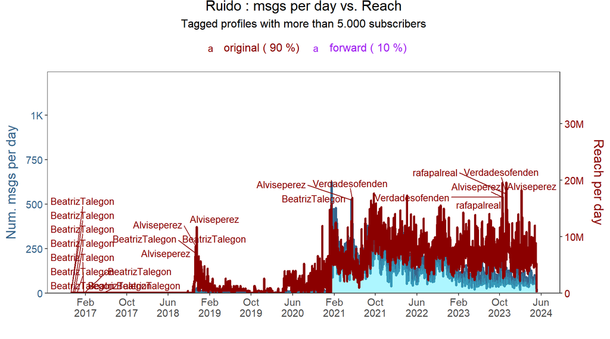

### Zoom

## msgs vs. forward

### Periodo total

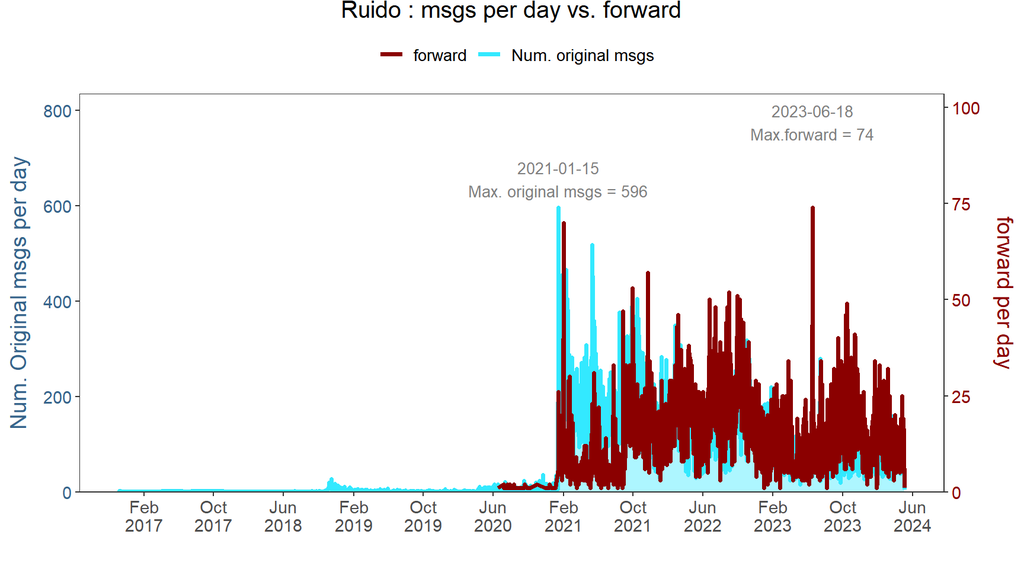

### Zoom msgs_vs_forward

## Referencias a dominios

### Periodo total

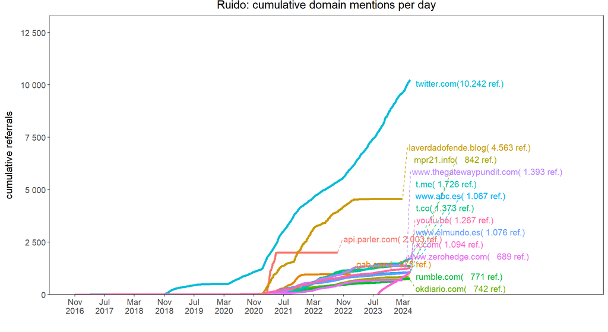

### Zoom

## msgs by community

Los siguientes scripts visualizan la evolución temporal con ARS. **Solo se ejecutan si se han clasificado los msgs**

Requiere haber realizado los pasos previos:

- Generar un fichero gdf con las relaciones de forward para Gephi mediante el notebook tg_summarize_channels.Rmd
- Generar un grafo con Gephi y exportar su tabla de datos
- Clasificar los msgs con el notebook tg_classify_msgs.Rmd

[figure not shown]

ciclo Análisis ARS: Evolución temporal con AR

- Se limita el número de comunidades a catorce, cifra que creo que es suficiente en la mayoría de los casos.
- Por compatibilidad con el análisis de ARS, se han elegido los ocho colores que Gephi asigna por defecto como lo primeros ocho colores y se han añadido seis más hasta completar los catorce.

Colores por defecto:

- #CC66FF RGB(204,102,255)
- #92D050 RGB(146,208,80)
- #00B0F0 RGB(0,176,240)
- #404040 RGB(64,64,64)
- #FF9900 RGB(255,153,0)
- #FF5050 RGB(255,80,80)
- #00D67F RGB(0,214,127)
- #F8CBAD RGB(248,203,173)
- #8A2E00 RGB(138,46,0)
- #993366 RGB(153,51,102)
- #0033CC RGB(0,51,204)
- #008E55 RGB(0,142,85)
- #45682D RGB(69,104,45)
- #702500 RGB(112,37,0)

### Periodo total msgs-community

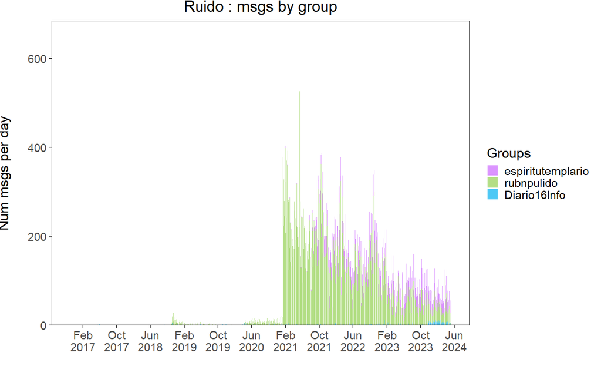

### Zoom msgs-community

## Contenido de los msgs por comunidades

### Periodo total

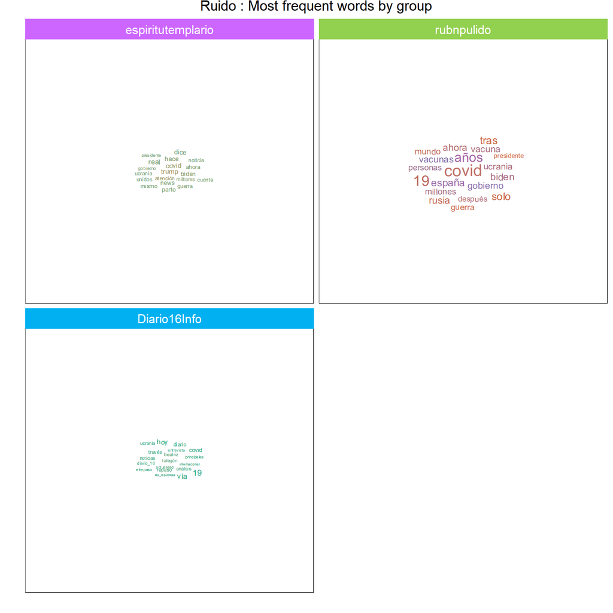

### Zoom